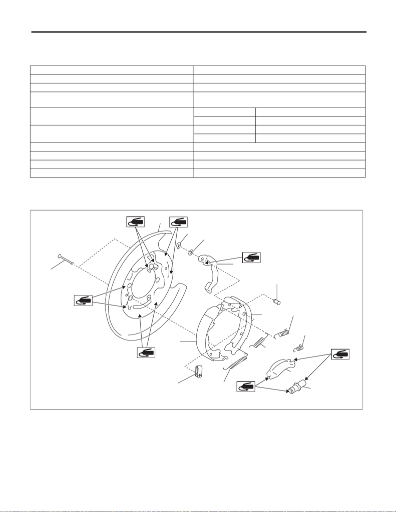

PB-2

General Description

PARKING BRAKE

1. General Description

A: SPECIFICATION

B: COMPONENT

1. PARKING BRAKE (REAR DISC BRAKE)

Item Specification

Type Drum in disc, duo servo type

Effective drum diameter mm (in) 190 (7.48)

Lining dimensions

(Length × Width × Thickness)

mm (in)

165.0 × 30.0 × 3.5

Inside diameter mm (in)

Standard 190 (7.48)

Limit 191 (7.52)

Lining thickness mm (in)

Standard 3.5 (0.14)

Limit 1.5 (0.059)

Clearance adjustment Manual adjustment

Operation method Manual lever type

Lever stroke Notches/N (kgf, lbf) 7 — 8/200 (20.4, 45)

(1) Back plate - rear brake (6) Parking brake shoe (secondary) (11) Spring - primary shoe return

(2) Retainer - rear brake (7) Spring - secondary shoe return (12) Spring - adjuster

(3) Spring washer - rear brake (8) Spring - strut (13) Spring - shoe clamp

(4) Parking lever - rear (9) Strut - brake (14) Parking brake shoe (primary)

(5) Pin - parking lever (10) Adjuster ASSY - rear brake (15) Pin - shoe hold-down

(15)

(1)

(2)

(3)

(4)

(5)

(6)

(7)

(10)

(9)

(8)

(11)

(13)

(12)

(14)

PB-00279

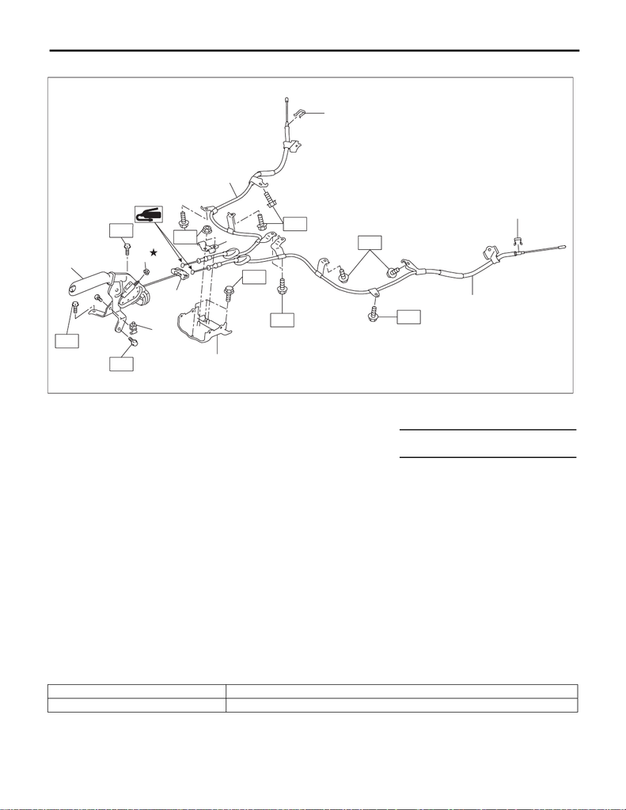

PB-3

General Description

PARKING BRAKE

2. PARKING BRAKE LEVER & CABLE

C: CAUTION

• When performing any work, always wear work clothes, a work cap and protective shoes. Additionally, wear

a helmet, protective goggles, etc. if necessary.

• When performing a repair, identify the cause of trouble and avoid unnecessary removal, disassembly and

replacement.

• Some vehicle components are extremely hot immediately after driving. Be wary of receiving burns from

heated parts.

• Use SUBARU genuine grease, the recommended or equivalent. Do not mix grease etc. of different grades

or manufacturers.

• Be sure to tighten fasteners including bolts and nuts to the specified torque.

• Always use the jack-up point when the shop jacks or rigid racks are used to support the vehicle.

• Apply grease onto sliding or revolving surfaces before installation.

• Be sure that the surface of brake disc, brake pad or brake shoe is free from grease or oil.

D: PREPARATION TOOL

1. GENERAL TOOL

(1) Lever ASSY - hand brake (5) Bracket (9) Cable ASSY - parking brake LH

(2) Switch ASSY - hand brake (6) Clamp A - hand brake cable

(3) Adjusting nut (self-locking nut) (7) Cable ASSY - parking brake RH Tightening torque: N·m (kgf-m, ft-lb)

(4) Equalizer (8) Clamp B - hand brake cable T: 18 (1.8, 13.3)

TOOL NAME REMARKS

Circuit tester Used for measuring resistance and voltage.

T

T

T

(7)

(8)

(8)

(9)

T

T

(5)

T

T

(2)

(4)

T

(1)

(3)

T

(6)

PB-00342